# Case Study für Deutschland

## Zweiter Teil der Case Study

Im zweiten Teil der Case Study werden Sie die eingelesenen und aufgearbeiteten Daten aus Teil 1 deskriptiv untersuchen. Hierbei erhalten Sie einen Eindruck von den Daten und können mögliche Zusammenhänge entdecken, indem Sie unterschiedliche Informationen visualisieren und auch in Tabellenform auswerten. Ziele des zweiten Teils der Case Study:

- Daten visualisieren und Zusammenhänge grafisch veranschaulichen
- Deskriptive Analysen mittels Korrelationstabellen und deskriptiven Tabellen anfertigen
- Das Verständnis wie Sie ihre Informationen zu bestimmten Fragestellungen möglichst effektiv aufbereiten
- Interaktive Grafiken erstellen

Sie erhalten durch deskriptive Analysen einen sehr guten Eindruck von den regionalen Unterschieden innerhalb Deutschlands. Das begleitende 3. RTutor Problem Set gibt Ihnen einen sehr guten Eindruck davon, wie die Unterschiede zwischen den einzelnen Ländern auf europäischer Ebene aussehen.

# Daten und Pakete laden

Nachdem wir uns im ersten Teil der Case Study alle Daten aus verschiedenen Datenquellen zusammengetragen und in R eingelesen haben, wollen wir in diesem zweiten Teil die darin enthaltenen Informationen analysieren, insbesondere visualisieren.

Hierzu laden wir uns die aus Teil 1 erstellten Datensätze:

```r
library(tidyverse)
library(skimr)
library(sf)
library(plotly)
library(kableExtra)
library(gt)
```

```r
# Daten einlesen
#einkommen <- readRDS("data/einkommen.rds")
bundesland <- readRDS("data/bundesland.rds")
landkreise <- readRDS("data/landkreise.rds")
bip_zeitreihe <- readRDS("data/bip_zeitreihe.rds")
gemeinden <- readRDS("data/gemeinden.rds")
gesamtdaten <- readRDS("data/gesamtdaten.rds")
schulden_bereinigt <- readRDS("data/schulden_bereinigt.rds")

# Aktuellstes Jahr der BIP-Zeitreihe, damit sich die Jahresangaben im Text
# automatisch an neue Daten anpassen
jahr_max <- max(bip_zeitreihe$Jahr)
```

# Deskriptive Analysen

## Univariate deskriptive Analysen

Wir wollen uns zu Beginn unserer Analysen einen Überblick über die Daten verschaffen. D.h. wie viele Landkreise haben wir in den Daten? Wie ist die Verteilung der Schulden, Arbeitslosigkeit und des BIP?

Hierfür wollen wir uns im ersten Schritt die Arbeitslosenquote berechnen. Die Schulden pro Kopf und das BIP pro Kopf hatten wir bereits in dem ersten Teil der Case-Study berechnet. Die Arbeitslosenquote wollen wir als $Arbeitslosenquote = Arbeitslose / (Erwerbstätige + Arbeitslose)$ berechnen. Im Nenner stehen damit alle Personen, die arbeiten oder Arbeit suchen. Achtung: Die Arbeitslosen zählt die Bundesagentur für Arbeit am **Wohnort**, die Erwerbstätigen aus der Volkswirtschaftlichen Gesamtrechnung werden dagegen am **Arbeitsort** gezählt. Für Städte mit vielen Einpendler:innen ist unsere Quote daher zu niedrig, für das Umland mit vielen Auspendler:innen zu hoch. Für große Regionen gleicht sich das weitgehend aus.

In den nächsten Abschnitten wollen wir uns die Parameter für die einzelnen Variablen dann genauer anschauen.

```r
# Zuerst wollen wir uns noch die Arbeitslosenquote pro Landkreis berechnen
gesamtdaten <- gesamtdaten |>
  mutate(alo_quote = (total_alo / (erw+total_alo))*100)
```

### Anzahl an Beobachtungen

Wir wollen zuerst einen Blick auf die Anzahl an Erwerbstätigen und Einwohnern in Deutschland werfen. Hier haben wir 46,0 Mio. Erwerbstätige und 77,3 Mio. Einwohner in Deutschland. Die Zahl der Erwerbstätigen umfasst alle Landkreise und kreisfreien Städte. Bei den Einwohnern fehlen dagegen Hamburg (1,8 Mio.), Berlin (3,8 Mio.), Bremen (0,6 Mio.) und Bremerhaven (0,1 Mio.), da wir die Einwohnerzahlen aus der Schuldenstatistik der Gemeinden übernommen haben, welche keine Stadtstaaten enthält. Die Daten wollen wir uns als einfachen Tibble Datensatz anzeigen lassen:

```r
# Wie viele Erwerbstätige und Einwohner (Einwohner ohne Berlin, Hamburg, Bremen und Bremerhaven) hat Deutschland?
gesamtdaten |>
  summarise(total_erw = sum(erw, na.rm=TRUE),
            total_einwohner = sum(Einwohner, na.rm=TRUE))
```

```
## # A tibble: 1 × 2
##   total_erw total_einwohner
##       <dbl>           <dbl>
## 1  45987000        77277808
```

Nun wollen wir uns die Variablen im Datensatz genauer anschauen. Eine Tabelle nur als Tibble darzustellen ist nicht besonders ansprechend. Wir können uns für einen ersten kurzen Überblick des `skimr`-Pakets bedienen:

```r
# Anschließend wollen wir eine Summary Statistic für alle Variablen ausgeben lassen
# Entfernen der Histogramme, damit alles auch schön in PDF gedruckt werden kann
gesamtdaten |>
  select(alo_quote, Schulden_pro_kopf_lk, bip_pro_kopf, landkreis_name) |>
  skim()
```

Data summary

| Name | select(…) |
| --- | --- |
| Number of rows | 400 |
| Number of columns | 4 |
| _______________________ |  |
| Column type frequency: |  |
| character | 1 |
| numeric | 3 |
| ________________________ |  |
| Group variables | None |

**Variable type: character**

| skim_variable | n_missing | complete_rate | min | max | empty | n_unique | whitespace |
| --- | --- | --- | --- | --- | --- | --- | --- |
| landkreis_name | 0 | 1 | 3 | 32 | 0 | 378 | 0 |

**Variable type: numeric**

| skim_variable | n_missing | complete_rate | mean | sd | p0 | p25 | p50 | p75 | p100 | hist |
| --- | --- | --- | --- | --- | --- | --- | --- | --- | --- | --- |
| alo_quote | 0 | 1.00 | 5.61 | 2.09 | 1.88 | 4.00 | 5.44 | 6.90 | 14.46 | ▇▇▅▁▁ |
| Schulden_pro_kopf_lk | 4 | 0.99 | 3223.38 | 2359.84 | 188.23 | 1660.58 | 2513.91 | 4041.37 | 18911.35 | ▇▂▁▁▁ |
| bip_pro_kopf | 0 | 1.00 | 47951.45 | 19941.49 | 21480.73 | 36300.64 | 42721.06 | 52178.33 | 193293.12 | ▇▂▁▁▁ |

Wir haben 400 individuelle Beobachtungen in unserem Datensatz. Hierbei handelt es sich um alle Landkreise und kreisfreien Städte in Deutschland. Stimmen diese Angaben? Für einen kurzen Konsistenzcheck wollen wir uns Wikipedia bedienen.

In Deutschland gibt es 294 Landkreise. Die Anzahl der Landkreise pro Bundesland finden wir [hier](https://de.wikipedia.org/wiki/Liste_der_Landkreise_in_Deutschland). Weiterhin gibt es in Deutschland 106 kreisfreie Städte, die genaue Auflistung finden wir [hier](https://de.wikipedia.org/wiki/Liste_der_kreisfreien_St%C3%A4dte_in_Deutschland). D.h. unsere 400 Landkreise und kreisfreien Städte sollten stimmen.

Jedoch gibt es nur 378 unterschiedliche Landkreis Namen in unserem Datensatz mit 400 unterschiedlichen Beobachtungen (Regionalschlüsseln). Dies kommt daher, dass z.B. die Stadt München eine Beobachtung ist und der Landkreis München eine weitere Beobachtung mit anderem Regionalschlüssel. D.h. der “landkreis_name” ist der Gleiche, jedoch ist der Regionalschlüssel ein anderer.

Für die Schulden und die Einwohnerzahlen fehlen uns leider Daten für *4* Landkreise, für das BIP und die Erwerbstätigen liegen dagegen für alle Landkreise Daten vor (fehlend: *0*). Diese Landkreise fehlen bei den Schulden und Einwohnern:

```r
gesamtdaten |>
  filter(is.na(Einwohner)) |>
  select(landkreis_name)
```

```
## # A tibble: 4 × 1
##   landkreis_name
##   <chr>
## 1 Hamburg
## 2 Bremen
## 3 Bremerhaven
## 4 Berlin
```

Dies sind die vier Stadtstaaten-Kreise. Ihre Schulden sind Landesschulden und daher nicht in der Schuldenstatistik der Gemeinden enthalten. Bei Analysen zu Schulden und Einwohnern können wir sie daher nicht berücksichtigen, bei der Arbeitslosenquote und dem BIP pro Kopf aber schon.

*Hinweis:* In einer früheren Version des ersten Teils der Case Study fehlten bei Hamburg und Berlin auch BIP und Erwerbstätige, da die beiden Städte in den BIP-Daten nur mit ihrem Länderschlüssel (`02` und `11`) geführt werden. Wie wir das korrigiert haben, steht im ersten Teil im Abschnitt “Sonderfall Stadtstaaten”. Ein gutes Beispiel dafür, warum man nach jedem Merge prüfen sollte, *welche* Beobachtungen `NA` sind.

### Beschreibung der Tabelle

**Arbeitslosenquote**

Im Durchschnitt liegt die Arbeitslosenquote in 2024 bei 5,61 Prozent. Dabei haben wir **alle** Arbeitslosen einbezogen, d.h. Leistungsbeziehende nach SGB II und SGB III. Ein kurzer Konsistenzcheck auf [Statista](https://de.statista.com/statistik/daten/studie/1224/umfrage/arbeitslosenquote-in-deutschland-seit-1995/) zeigt uns die dort gemeldete Arbeitslosenquote von 6,0% für 2024 (siehe auch den [Jahresrückblick 2024 der Bundesagentur für Arbeit](https://www.arbeitsagentur.de/presse/2025-02-jahresrueckblick-2024)). Unser Wert ist allerdings ein einfacher Mittelwert über die Landkreise, in dem z.B. Berlin genauso viel zählt wie ein kleiner Landkreis. Berechnen wir die Quote für Deutschland aus den Summen (alle Arbeitslosen geteilt durch alle Erwerbstätigen plus Arbeitslosen), erhalten wir 5,71%. Der verbleibende Unterschied zur amtlichen Quote liegt am Nenner: Die Bundesagentur für Arbeit bezieht die Arbeitslosen auf alle zivilen Erwerbspersonen am Wohnort, wir auf die Erwerbstätigen aus der Volkswirtschaftlichen Gesamtrechnung, die am Arbeitsort gezählt werden. Die Standardabweichung beträgt 2,09 und zeigt damit, dass es in Deutschland deutliche regionale Unterschiede bzgl. der Arbeitslosenquote gibt. Ein Blick auf die Verteilung zeigt, dass der Landkreis mit der geringsten Arbeitslosenquote (der Landkreis München, nicht die gleichnamige Stadt) nur eine Arbeitslosenquote von 1,88% (`p0` in der obigen Tabelle) aufweist und der Landkreis mit der höchsten Arbeitslosenquote (Gelsenkirchen) eine von 14,46% (`p100` in der obigen Tabelle). Auf Platz 2 der niedrigsten Quoten liegt übrigens Ulm, auch eine Folge der vielen Einpendler:innen. Der Mittelwert liegt damit weit unter dem spanischen Durchschnitt ([rund 11,4% im Jahr 2024](https://de.statista.com/statistik/daten/studie/17327/umfrage/arbeitslosenquote-in-spanien/)), einzelne Landkreise wie Gelsenkirchen liegen aber sogar darüber. Es gibt also auch in Deutschland Regionen mit einer sehr hohen Arbeitslosenquote.

**Verschuldung pro Kopf**

Bei der Verschuldung der Landkreise ergibt sich ein ähnliches Bild. Durchschnittlich beträgt die Verschuldung der Landkreise 3.223€, mit einer Standardabweichung von 2.360€. D.h. auch hier gibt es eine große Bandbreite bzgl. der Verschuldung einzelner Landkreise.

**BIP pro Kopf**

Wie schon bei der Arbeitslosenquote und der Verschuldung sehen wir auch bei dem BIP pro Kopf deutliche Unterschiede zwischen den einzelnen Landkreisen in Deutschland. Im Durchschnitt liegt das BIP pro Kopf in den Landkreisen bei 47.951€, jedoch haben wir eine Standardabweichung von 19.941€, was zuerst nach sehr viel aussieht. Dies könnte jedoch an einzelnen Landkreisen liegen (so hat ein Landkreis bspw. ein BIP pro Kopf von 193.293€). Da der Median des BIP pro Kopf bei 42.721€ liegt haben wir hier schon einen Hinweis, dass das BIP pro Kopf vermutlich *nicht* normalverteilt über alle Landkreise ist und es wohl einzelne Ausreißer in den Daten gibt.

## Summary Statistics auf Bundeslandebene für die Arbeitslosigkeit

Nachdem wir im vorherigen Abschnitt bereits gesehen haben, dass es wohl deutliche regionale Unterschiede bei allen Variablen geben muss, wollen wir uns nun noch die Arbeitslosenquote auf Bundeslandebene anschauen. Erinnern wir uns daran das wir hier Querschnittsdaten für das Jahr 2024 für alle deutschen Landkreise betrachten. Weiterhin hat uns die vorherige Tabelle bereits gezeigt, dass wir mit “missing Values” rechnen müssen (`n_missing` bei der skimr-Tabelle). Um nun einen ersten Überblick über die regionale Verteilung der Arbeitslosenquote in 2024 zu gewinnen schauen wir uns die Arbeitslosenquote auf Bundeslandebene an, aggregiert über die Landkreise eines Bundeslandes. Hierzu wollen wir uns des Pakets `kableExtra` bedienen um schönere Tabellen zu erstellen:

```r
bula_data <- gesamtdaten |>
  group_by( bundesland_name ) |>
  summarise(mean_alo = mean(alo_quote),
            sd_alo = sd(alo_quote),
            median_alo = median(alo_quote), .groups = 'drop')

bula_data |>
  arrange( mean_alo ) |>
  filter( !is.na(mean_alo) ) -> bula_tabelle

# Zeilen der ostdeutschen Bundesländer bestimmen (nicht per Hand abzählen:
# sobald sich Daten oder Sortierung ändern, wären feste Zeilennummern falsch)
ost_laender <- c("Brandenburg", "Mecklenburg-Vorpommern", "Sachsen", "Sachsen-Anhalt", "Thüringen")
ost_zeilen  <- which(bula_tabelle$bundesland_name %in% ost_laender)

bula_tabelle |>
  kbl(col.names = c("Bundesland",
                    "Mittelwert",
                    "Std.",
                    "Median"), digits = 2) |>
  kable_styling(bootstrap_options = c("striped", "hover", "condensed", "responsive")) |>
  kable_paper(full_width = F) |>
  row_spec(ost_zeilen, bold = T, color = "white", background = "#BBBBBB") |>
  add_header_above(c(" " = 1, "Arbeitslosenquote" = 3), align = "c") |>
  footnote(general = "Berlin und Hamburg bestehen aus nur einem Kreis, daher gibt es für sie keine Standardabweichung.",
           general_title = "Bitte beachten: ",
           number = "Die ostdeutschen Bundesländer sind grau hinterlegt.")
```

| Bundesland | Arbeitslosenquote Mittelwert | Arbeitslosenquote Std. | Arbeitslosenquote Median |
| --- | --- | --- | --- |
| Bayern | 3.60 | 0.80 | 3.51 |
| Baden-Württemberg | 4.10 | 0.83 | 4.12 |
| Hessen | 5.50 | 1.28 | 5.61 |
| Rheinland-Pfalz | 5.84 | 1.52 | 5.68 |
| Schleswig-Holstein | 5.98 | 0.80 | 6.12 |
| Hamburg | 6.11 | NA | 6.11 |
| Niedersachsen | 6.18 | 1.77 | 6.37 |
| Saarland | 6.33 | 1.85 | 5.89 |
| Sachsen | 6.47 | 0.88 | 6.27 |
| Thüringen | 6.68 | 1.64 | 6.12 |
| Brandenburg | 7.06 | 1.63 | 7.19 |
| Nordrhein-Westfalen | 7.36 | 2.33 | 6.94 |
| Mecklenburg-Vorpommern | 7.94 | 1.20 | 8.26 |
| Sachsen-Anhalt | 8.09 | 1.48 | 7.89 |
| Berlin | 8.47 | NA | 8.47 |
| Bremen | 10.24 | 3.56 | 10.24 |

Bitte beachten:  
Berlin und Hamburg bestehen aus nur einem Kreis, daher gibt es für sie keine Standardabweichung.  
<sup>1</sup> Die ostdeutschen Bundesländer sind grau hinterlegt.

Hier sehen wir insbesondere für Landkreise in Bayern und Baden-Württemberg Arbeitslosenquoten von durchschnittlich rund 4% oder darunter und für Landkreise in Sachsen-Anhalt, Mecklenburg-Vorpommern, Nordrhein-Westfalen und Brandenburg sowie für die Stadtstaaten Bremen und Berlin Arbeitslosenquoten von durchschnittlich über 7%. Vorsicht bei Bremen: Der Wert ist das einfache Mittel aus der Stadt Bremen (7,7%) und Bremerhaven (12,8%). Da die Stadt Bremen rund sechsmal so viele Erwerbstätige hat, liegt die Quote des Landes Bremen (erst summieren, dann teilen) nur bei 8,5%. Die Tabelle zeigt also das Mittel der *Landkreise*, nicht die Quote der *Länder*. Es fällt weiterhin auf, dass die Landkreise in ehemaligen ostdeutschen Bundesländern tendenziell höhere Arbeitslosenquoten aufweisen. Weiterhin ist die Standardabweichung, d.h. die Streuung um den Mittelwert, insgesamt für die Landkreise der einzelnen Bundesländer oft vergleichbar (in Nordrhein-Westfalen und Bremen jedoch recht hoch). Mit rund einem Prozentpunkt ist die Standardabweichung oft moderat, d.h. die Landkreise pro Bundesland sind recht ähnlich zueinander. Bei einer Standardabweichung von 2,33 Prozentpunkten ist die Standardabweichung in Nordrhein-Westfalen hoch, was auf große regionale Unterschiede zwischen den einzelnen Landkreisen schließen lässt. Der Median für die Arbeitslosenquote der Landkreise liegt recht nahe am Mittelwert, was auch darauf hindeutet, dass die Landkreise in den einzelnen Bundesländern sich nicht stark voneinander unterscheiden. Da wir hier tendenziell größere Unterschiede zwischen Ost- und Westdeutschland festgestellt haben wollen wir uns eine Dummyvariable “ost” generieren, welche 0 für alle ehemaligen westdeutschen und 1 für alle ehemaligen ostdeutschen Bundesländer ist. Berlin ordnen wir dabei Westdeutschland zu, da Ost- und Westberlin in den Daten nicht getrennt werden und Berlin als Stadtstaat ohnehin eine Sonderrolle hat:

```r
gesamtdaten <- gesamtdaten |>
  mutate( ost = as.factor(ifelse(bundesland_name %in% c("Brandenburg", "Mecklenburg-Vorpommern", "Sachsen", "Sachsen-Anhalt", "Thüringen"), 1, 0)),
          ost_name = ifelse(ost == 1, "Ostdeutschland", "Westdeutschland"))
```

Durch diese Aufteilung treten die Unterschiede in der Arbeitslosenquote zwischen den ehemaligen ost- und westdeutschen Landkreisen besonders stark zutage. Insbesondere wenn wir uns die Quantile anschauen: Im **25% Quantil** in **Ostdeutschland** ist die Arbeitslosenquote bei **6,03%**, in **Westdeutschland** ist das **75% Quantil** bei einer Arbeitslosenquote von **6,45%**. D.h. drei Viertel der ostdeutschen Landkreise haben eine Arbeitslosenquote über diesem ersten Wert, drei Viertel der westdeutschen Landkreise eine Quote unter dem zweiten. Die mittleren Hälften der beiden Verteilungen überschneiden sich also nur in einem schmalen Bereich.

```r
gesamtdaten |>
  group_by(ost_name) |>
  summarise(mean_alo = mean(alo_quote, na.rm = T), sd_alo = sd(alo_quote, na.rm = T), min_alo = min(alo_quote, na.rm = T), q25 = quantile(alo_quote, c(0.25), na.rm = T), median_alo = median(alo_quote, na.rm = T), q75 = quantile(alo_quote, 0.75, na.rm = T), max_alo = max(alo_quote, na.rm = T)) |>
  ungroup() |>
  kbl(col.names = c("Bundesland",
                    "Mittelwert",
                    "Std.",
                    "Minimum",
                    "P25",
                    "Median",
                    "P75",
                    "Maximum"), digits = 2) |>
  kable_styling(bootstrap_options = c("striped", "hover", "condensed", "responsive")) |>
  kable_paper(full_width = F) |>
  add_header_above(c(" " = 1, "Arbeitslosenquote" = 7), align = "c") |>
  footnote(general = "Berlin ist Westdeutschland zugeordnet.",
           general_title = "Bitte beachten: ")
```

| Bundesland | Arbeitslosenquote Mittelwert | Arbeitslosenquote Std. | Arbeitslosenquote Minimum | Arbeitslosenquote P25 | Arbeitslosenquote Median | Arbeitslosenquote P75 | Arbeitslosenquote Maximum |
| --- | --- | --- | --- | --- | --- | --- | --- |
| Ostdeutschland | 7.13 | 1.55 | 4.17 | 6.03 | 7.02 | 8.00 | 11.61 |
| Westdeutschland | 5.26 | 2.05 | 1.88 | 3.67 | 4.73 | 6.45 | 14.46 |

Bitte beachten:  
Berlin ist Westdeutschland zugeordnet.

Nun haben wir uns ein erstes Bild über die Daten, insbesondere die Arbeitslosigkeit in 2024 machen können. Natürlich sollten die von uns heruntergeladenen Informationen zum BIP und den Schulden der einzelnen Landkreise auch berücksichtigt werden und wir können diese unseren Tabellen hinzufügen:

```r
bula_data_all <- gesamtdaten |>
  group_by( bundesland_name ) |>
  summarise(mean_alo = mean(alo_quote),
            sd_alo = sd(alo_quote),
            mean_bip_kopf = mean(bip_pro_kopf),
            sd_bip_kopf = sd(bip_pro_kopf),
            mean_schulden_kopf = mean(Schulden_gesamt/Einwohner),
            sd_schulden = sd(Schulden_gesamt/Einwohner), .groups = 'drop')

bula_tabelle_all <- bula_data_all |>
  arrange( mean_alo ) |>
  filter( !is.na(mean_schulden_kopf) )

bula_tabelle_all |>
  kbl(col.names = c("Bundesland", "Mittelwert","Std.","Mittelwert","Std.", "Mittelwert","Std."), digits = 2, format = "html",
      caption = "Deskriptive Tabelle komplett") |>
  #kbl(col.names = c("Mittelwert","Std.", "Mittelwert","Std."), digits = 0) |>
  kable_styling(bootstrap_options = c("striped", "hover", "condensed", "responsive")) |>
  kable_paper(full_width = F) |>
  row_spec(which(bula_tabelle_all$bundesland_name %in% ost_laender), bold = T, color = "white", background = "#BBBBBB") |>
  add_header_above(c(" " = 1, "Arbeitslosenquote" = 2, "BIP pro Kopf" = 2, "Schulden pro Kopf" = 2), align = "c") |>
  footnote(general = "Wir haben keine Informationen zu Berlin, Hamburg und Bremen bzgl. ihrer Schulden pro Kopf, weshalb sie nicht in der Tabelle aufgeführt wurden.",
           general_title = "Bitte beachten: ",
           number = "Die ostdeutschen Bundesländer sind grau hinterlegt.")
```

Deskriptive Tabelle komplett

| Bundesland | Arbeitslosenquote Mittelwert | Arbeitslosenquote Std. | BIP pro Kopf Mittelwert | BIP pro Kopf Std. | Schulden pro Kopf Mittelwert | Schulden pro Kopf Std. |
| --- | --- | --- | --- | --- | --- | --- |
| Bayern | 3.60 | 0.80 | 55132.65 | 24310.30 | 2421.92 | 1760.90 |
| Baden-Württemberg | 4.10 | 0.83 | 55750.24 | 18616.08 | 3460.99 | 2720.58 |
| Hessen | 5.50 | 1.28 | 52582.10 | 22245.54 | 4329.39 | 3814.87 |
| Rheinland-Pfalz | 5.84 | 1.52 | 43915.33 | 15809.89 | 2665.61 | 2585.69 |
| Schleswig-Holstein | 5.98 | 0.80 | 43454.42 | 10333.18 | 3529.59 | 1474.34 |
| Niedersachsen | 6.18 | 1.77 | 46410.73 | 26052.45 | 2756.76 | 1889.72 |
| Saarland | 6.33 | 1.85 | 38997.57 | 9227.56 | 5136.04 | 1123.91 |
| Sachsen | 6.47 | 0.88 | 38130.24 | 7507.53 | 2556.30 | 1179.08 |
| Thüringen | 6.68 | 1.64 | 35494.55 | 7258.04 | 2827.03 | 637.22 |
| Brandenburg | 7.06 | 1.63 | 40426.24 | 9206.02 | 2456.88 | 1313.44 |
| Nordrhein-Westfalen | 7.36 | 2.33 | 45914.95 | 14357.72 | 4845.94 | 2612.72 |
| Mecklenburg-Vorpommern | 7.94 | 1.20 | 39548.21 | 8745.10 | 4393.49 | 2266.53 |
| Sachsen-Anhalt | 8.09 | 1.48 | 36335.33 | 5195.32 | 3121.24 | 1730.45 |

Bitte beachten:  
Wir haben keine Informationen zu Berlin, Hamburg und Bremen bzgl. ihrer Schulden pro Kopf, weshalb sie nicht in der Tabelle aufgeführt wurden.  
<sup>1</sup> Die ostdeutschen Bundesländer sind grau hinterlegt.

Was wir hier gut sehen können ist folgendes: Für alle Bundesländer in denen wir niedrige Arbeitslosenquoten pro Landkreis haben gibt es auch durchschnittlich ein hohes BIP pro Kopf über die Landkreise des Bundeslandes hinweg. D.h. speziell in unserem Datensatz von 2024 ist in den Bundesländern mit einer durchschnittlich hohen Wirtschaftsleistung in den Landkreisen die Arbeitslosenquote gering. Insbesondere für ostdeutsche Landkreise ist das BIP pro Kopf durchschnittlich *niedriger* als für die meisten westdeutschen Landkreise, auch wenn sich die Werte am unteren Rand der westdeutschen Länder und am oberen Rand der ostdeutschen Länder inzwischen überschneiden: Im Mittel seiner Landkreise liegt das Saarland (38.998€) sogar unter Brandenburg (40.426€). Bei den Schulden ist dieser Sachverhalt weniger deutlich ausgeprägt. Es gibt westdeutsche Landkreise, wie z.B. in den Bundesländern Bayern und Niedersachsen, mit sehr geringen Schulden pro Kopf, doch dies trifft auch für Landkreise in Sachsen oder Brandenburg zu. Insbesondere Landkreise im Saarland haben durchschnittlich eine sehr hohe Verschuldung pro Kopf von 5.136€.

Allein durch den Mittelwert und die Standardabweichung konnten wir bereits sehr viel über unsere Daten lernen und haben hier schon einige deutliche Unterschiede zwischen ostdeutschen und westdeutschen Landkreisen feststellen können.

Wir können in deskriptiven Statistiken neben Querschnittsdaten für ein bestimmtes Jahr auch Paneldaten analysieren. Hierbei können wir den Mittelwert und die Standardabweichung über den kompletten Datensatz bilden, wie in den Querschnittsdaten, oder wir können Trends in den Daten beschreiben. Eine solche Trendanalyse wollen wir mit der folgenden Tabelle unternehmen. Dieses mal nehmen wir für unsere Analyse das Paket `gt`.

```r
bundesland_name <- gesamtdaten |>
  select(bundesland_name, bundesland, ost_name) |>
  distinct() |>
  rename(Regionalschluessel = bundesland)

# Vergleichsjahre: zwei historische Anker und das aktuellste Jahr der Zeitreihe
jahre <- c(1992, 2007, jahr_max)

bip_daten <- bip_zeitreihe |>
  left_join(bundesland_name, by="Regionalschluessel") |>
  filter( nchar(Regionalschluessel) == 2 ) |>
  filter( Regionalschluessel != 17) |> #17 = Deutschland
  filter( Jahr %in% jahre) |>
  group_by(ost_name, bundesland_name, Jahr) |>
  summarise( mean_bip = mean(bip_pro_kopf)) |>
  ungroup()


bip_daten |>
  pivot_wider(names_from = "Jahr", values_from = "mean_bip") |>
  gt(groupname_col = "ost_name") |>
  fmt_number(columns = all_of(as.character(jahre)), decimals = 0) |>
  fmt_currency(columns = all_of(as.character(jahre)), rows = 1, currency = "EUR", decimals = 0) |>
  cols_align(align = "left",
             columns = c(`bundesland_name`)) |>
  cols_label(bundesland_name = md("")) |>
  tab_spanner(label = "BIP pro Kopf in den einzelnen Bundesländern", columns = all_of(as.character(jahre))) |>
  tab_style(
    style = cell_text(color = "black", weight = "bold"),
    locations = list(
      cells_column_spanners(everything()),
      cells_column_labels(everything())
    )
  ) |>
  tab_options(
    row_group.border.top.width = px(3),
    row_group.border.top.color = "black",
    row_group.border.bottom.color = "black",
    table_body.hlines.color = "white",
    table.border.top.color = "white",
    table.border.top.width = px(3),
    table.border.bottom.color = "white",
    table.border.bottom.width = px(3),
    column_labels.border.bottom.color = "black",
    column_labels.border.bottom.width = px(2),
  ) |>
  tab_source_note(md("**Daten**: Statistische Ämter Deutschlands<br>**Inspiration**: @thomas_mock"))
```

|  | BIP pro Kopf in den einzelnen Bundesländern 1992 | BIP pro Kopf in den einzelnen Bundesländern 2007 | BIP pro Kopf in den einzelnen Bundesländern 2024 |
| --- | --- | --- | --- |
| Ostdeutschland |  |  |  |
| Brandenburg | €9,756 | €21,609 | €39,665 |
| Mecklenburg-Vorpommern | 9,491 | 20,295 | 38,612 |
| Sachsen | 9,866 | 22,647 | 40,259 |
| Sachsen-Anhalt | 9,204 | 21,073 | 37,155 |
| Thüringen | 8,966 | 20,922 | 36,890 |
| Westdeutschland |  |  |  |
| Baden-Württemberg | 25,538 | 36,385 | 58,018 |
| Bayern | 24,338 | 35,502 | 60,258 |
| Berlin | 21,944 | 29,596 | 56,739 |
| Bremen | 28,600 | 41,940 | 58,638 |
| Hamburg | 38,090 | 55,288 | 87,688 |
| Hessen | 27,139 | 38,561 | 59,190 |
| Niedersachsen | 20,510 | 27,953 | 48,113 |
| Nordrhein-Westfalen | 22,914 | 31,391 | 48,810 |
| Rheinland-Pfalz | 20,876 | 27,313 | 43,808 |
| Saarland | 20,791 | 30,961 | 41,632 |
| Schleswig-Holstein | 20,383 | 25,564 | 42,733 |

**Daten**: Statistische Ämter Deutschlands **Inspiration**: @thomas_mock

Auch in dieser Tabelle treten die Unterschiede zwischen westdeutschen und ostdeutschen Bundesländern zutage (die Tabelle zeigt das BIP pro Kopf der Länder, nicht den Mittelwert ihrer Landkreise). Während alle westdeutschen Bundesländer bereits im Jahr 1992 ein BIP pro Kopf von über 20 000€ aufweisen konnten, hatten die ostdeutschen Bundesländer diese Schwelle gerade so im Jahr 2007 erreicht. Jedoch gibt es seit dem Jahr 1992 einen Aufholprozess der ostdeutschen an die westdeutschen Bundesländer. Dieser Prozess fand jedoch hauptsächlich in den Jahren direkt nach der Wende statt. Z.B. lag das BIP pro Kopf des Landes Thüringen im Jahr 1992 bei nur 35,1% des BIP pro Kopf von Baden-Württemberg. In 2007 kletterte der Anteil bereits auf 57,5% und in 2024 liegt er bei 63,6%. Durch die Ergebnisse unserer Tabelle bestärkt, könnten wir vermuten das die Erneuerung der Infrastruktur und der Ansiedlung neuer Industriezweige in den ostdeutschen Landkreisen zu einem schnelleren Wachstum dieser Landkreise direkt nach der Wende und in den 1990er Jahren geführt hat. Dieses Wachstum hat sich jedoch in den letzten Jahren deutlich verlangsamt und es kommt nur noch zu einer sehr moderaten Anpassung des BIP pro Kopf.

## Visualisierung der Unterschiede

Tabellen sind hilfreich um Informationen kompakt zu präsentieren. Jedoch ist es oft ebenso wichtig (und manchmal für ihre Argumentation umso wichtiger) Erkenntnisse visuell zu veranschaulichen. In diesem Abschnitt wollen wir mehr über die Zusammensetzung jeder Variablen erfahren und dafür Grafiken verwenden.

### Arbeitslosenquote

Die Variable, welche uns besonders interessiert ist die Arbeitslosenquote, insbesondere da Ihr Cousin gemeint hat, dass Deutschland kein Problem mit der Arbeitslosigkeit hat. Wir wollen hier alle Datenpunkte zeigen, d.h. die Arbeitslosenquote eines jeden Landkreises für das Jahr 2024, getrennt nach Ost- und Westdeutschland. Weiterhin wollen wir unsere Grafik um einen Boxplot erweitern um einen Vergleich des Medians der Arbeitslosenquote in Ost- und Westdeutschland zu ermöglichen.

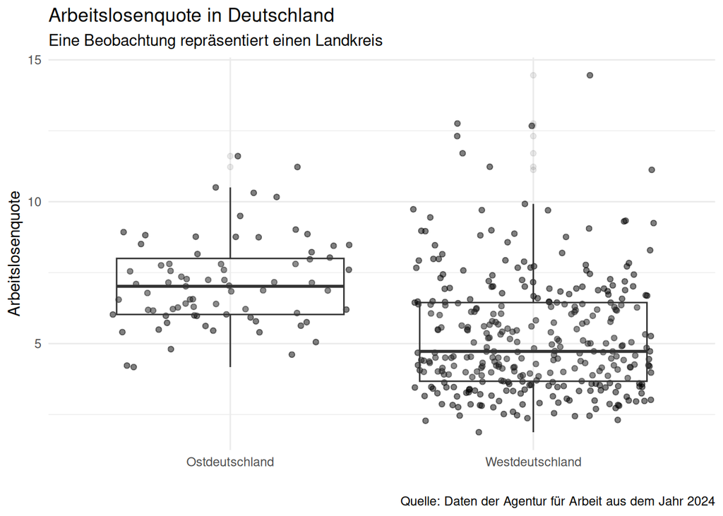

```r
alo_quote_jitter <- gesamtdaten |>
  select(alo_quote, landkreis_name, bundesland_name, ost_name) |>
  ggplot(aes(x = ost_name, y=alo_quote)) +
  geom_jitter(alpha=0.5) +
  geom_boxplot(alpha = 0.1) +
  theme_minimal() +
  labs(title = "Arbeitslosenquote in Deutschland",
       subtitle = "Eine Beobachtung repräsentiert einen Landkreis",
       x = "",
       y = "Arbeitslosenquote",
       caption = "Quelle: Daten der Agentur für Arbeit aus dem Jahr 2024")

alo_quote_jitter
```

Das Schaubild zeigt uns zum Einen, dass es deutlich mehr westdeutsche, wie ostdeutsche Landkreise gibt (nicht verwunderlich), aber auch, dass gut die Hälfte der westdeutschen Landkreise (54%) weniger als 5% Arbeitslosigkeit aufweist, wohingegen der größte Teil aller ostdeutschen Landkreise mehr als 5% Arbeitslosigkeit aufweist. Selbst der ostdeutsche Landkreis mit der niedrigsten Arbeitslosenquote ist nur leicht unter dem Median in Westdeutschland. Jedoch können wir konstatieren, dass Ihr Cousin recht hatte mit seiner Behauptung, denn es gibt sowohl in Ost als auch in Westdeutschland nur sehr wenige Landkreise welche eine Arbeitslosenquote von mehr als 10% haben. In Spanien liegt die Arbeitslosenquote [insgesamt bei rund 11%](https://ec.europa.eu/eurostat/databrowser/view/une_rt_a/default/table), in vielen Regionen deutlich darüber. Nichtsdestotrotz sind auch in Deutschland regionale Unterschiede erkennbar, welche wir insbesondere im dritten Teil der Case Study zu erklären versuchen. Als mögliche Faktoren, welche die Arbeitslosenquote erklären könnten, wollen wir hier das BIP pro Kopf und die Pro-Kopf-Verschuldung näher untersuchen.

Wir haben nun auch noch die Möglichkeit bestimmte Regionen in unterschiedlichen Farben zu markieren. Wollen wir beispielsweise alle Landkreise aus Baden-Württemberg hervorheben, so können wir diese beispielsweise rot einfärben und bekommen dadurch einen Eindruck wo Baden-Württemberg im deutschlandweiten Vergleich der Arbeitslosenquote pro Landkreis steht.

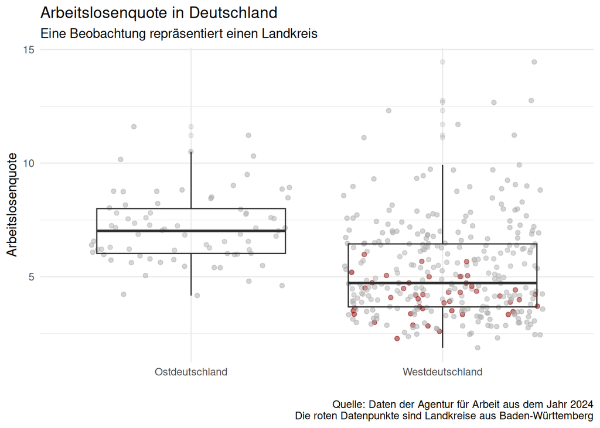

```r
alo_quote_jitter_farbe <- gesamtdaten |>
  select(alo_quote, landkreis_name, bundesland_name, ost_name) |>
  mutate(baden_wuerttemberg = as.factor(ifelse(bundesland_name == "Baden-Württemberg", 1, 0))) |>
  ggplot(aes(x = ost_name, y=alo_quote)) +
  geom_jitter(alpha=0.5, aes(color = ifelse(baden_wuerttemberg == 1, "darkred", "darkgrey"))) +
  scale_color_identity() +
  geom_boxplot(alpha = 0.1) +
  theme_minimal() +
  labs(title = "Arbeitslosenquote in Deutschland",
       subtitle = "Eine Beobachtung repräsentiert einen Landkreis",
       x = "",
       y = "Arbeitslosenquote",
       caption = "Quelle: Daten der Agentur für Arbeit aus dem Jahr 2024\nDie roten Datenpunkte sind Landkreise aus Baden-Württemberg") +
  theme(legend.position = "none")

alo_quote_jitter_farbe
```

*Hinweis zur vorherigen Grafik:* Falls wir dem Leser etwas mehr Freiheiten einräumen möchten und unsere Grafik als HTML Datei übergeben, so können wir auch eine interaktive Grafik nutzen. So kann der Leser mit unserer Ausarbeitung interagieren:

```r
# Zusätzlich Info um welchen Landkreis es sich handelt
alo_quote_jitter_plotly <- gesamtdaten |>
  select(alo_quote, landkreis_name, bundesland_name, ost_name) |>
  mutate(baden_wuerttemberg = as.factor(ifelse(bundesland_name == "Baden-Württemberg", "Baden-Württemberg", "Other"))) |>
  ggplot(aes(x = ost_name, y=alo_quote, group = landkreis_name)) +
  geom_jitter(alpha=0.5, aes(group = baden_wuerttemberg, colour = baden_wuerttemberg)) +
  geom_boxplot(alpha = 0.1) +
  theme_minimal() +
  labs(title = "Arbeitslosenquote in Deutschland",
       subtitle = "Eine Beobachtung repräsentiert einen Landkreis",
       x = "",
       y = "Arbeitslosenquote",
       caption = "Quelle: Daten der Bundesagentur Agentur für Arbeit aus dem Jahr 2024.") +
  scale_colour_manual(values = c("Baden-Württemberg" = "darkred", "Other" = "grey")) +
  guides(colour = "none")

ggplotly(alo_quote_jitter_plotly)
```

[interactive chart not shown]

### Bruttoinlandsprodukt pro Kopf

Wir haben im vorherigen Abschnitt gesehen, dass es durchaus deutliche regionale Unterschiede in der Arbeitslosenquote in 2024 gibt. Doch was könnten die Treiber dafür sein?

In diesem Unterabschnitt wollen wir uns das Bruttoinlandsprodukt pro Kopf auf Landkreisebene näher anschauen. Hierbei haben wir nicht nur die Daten für 2024, sondern können uns einer längeren Zeitreihe bedienen. Somit können wir uns die Entwicklung des BIP pro Kopf in den ehemaligen ost- und westdeutschen Bundesländern näher anschauen. Diese Zeitreihen sind für uns nützliche Hinweise, denn dadurch können wir sehen:

- ob es auch regionale Unterschiede im BIP pro Kopf gibt und nicht nur in der Arbeitslosenquote
- ob die regionalen Unterschiede schon längere Zeit bestehen
- ob die regionalen Unterschiede sich vergrößern oder verkleinern

Das Bruttoinlandsprodukt stellt die wichtigste gesamtwirtschaftliche Kenngröße dar. Es gibt Aufschluss darüber, wie viele Güter und Dienstleistungen in dem jeweiligen Landkreis produziert wurden. Falls das BIP in einem Landkreis hoch ist könnte dies unter anderem daran liegen, dass

- viele Personen in diesem Landkreis erwerbstätig sind,
- oder das die Erwerbstätigen in Branchen mit hoher Produktivität arbeiten.

Falls der erste Punkt zutrifft sollte ein hohes BIP pro Kopf (man beachte das hier das BIP pro Einwohner berechnet wird) auch mit einer niedrigeren Arbeitslosenquote einhergehen.

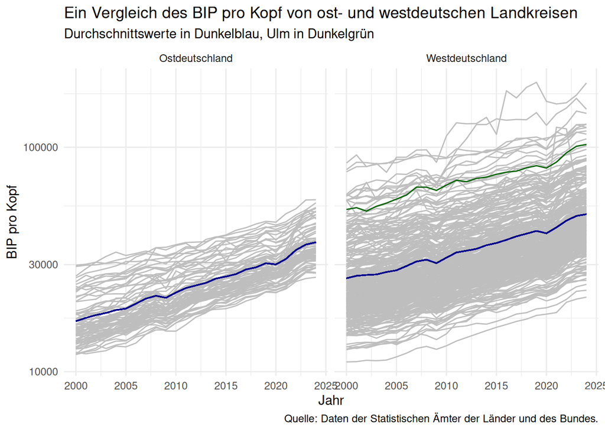

```r
# Zuerst die Information zu landkreis_name und bundesland_name zum Datensatz bip_zeitreihe hinzumergen
namen <- gesamtdaten |>
  select(Regionalschluessel, bundesland_name, landkreis_name, ost_name)

# Nur Landkreise behalten, die auch in gesamtdaten vorkommen (Kreisgebietsreformen
# können dazu führen, dass alte Kreise in der BIP-Zeitreihe noch auftauchen)

bip_zeitreihe_namen <- bip_zeitreihe |>
  filter( nchar(Regionalschluessel) == 5) |>
  left_join(namen, by="Regionalschluessel") |>
  #Der Kreis Eisenach wird in den BIP Daten extra aufgeführt, aber in den Daten zur Verschuldung und Arbeitslosigkeit nicht, daher entfernen wir diesen aus unserer Betrachtung
  filter(!is.na(landkreis_name))

options(scipen = 5)
plot_bip <- bip_zeitreihe_namen |>
  filter( Jahr >= 2000 ) |>
  group_by(ost_name, Jahr) |>
  mutate( durchschnitt = mean(bip_pro_kopf),
          ulm = ifelse(landkreis_name == "Ulm", bip_pro_kopf,NA)) |>
  ggplot() +
  geom_line(aes(x = Jahr, y = bip_pro_kopf, group = Regionalschluessel), color = "grey") +
  geom_line(aes(x = Jahr, y = durchschnitt, group = Regionalschluessel), color = "darkblue") +
  geom_line(aes(x = Jahr, y = ulm, group = Regionalschluessel), color = "darkgreen") +
  scale_y_continuous(trans = "log10") +
  theme_minimal() +
  facet_wrap(ost_name ~ .) +
  theme(legend.position = "none") +
  labs(title = "Ein Vergleich des BIP pro Kopf von ost- und westdeutschen Landkreisen",
       subtitle = "Durchschnittswerte in Dunkelblau, Ulm in Dunkelgrün",
       caption = "Quelle: Daten der Statistischen Ämter der Länder und des Bundes.",
       x = "Jahr",
       y = "BIP pro Kopf")

plot_bip
```

Das Niveau des BIP pro Kopf ist in den ostdeutschen Bundesländern deutlich niedriger als in den westdeutschen. Insbesondere wenn wir uns die logarithmische Skalierung der y-Achse anschauen, so können wir doch deutliche Unterschiede erkennen. Beispielsweise ist das durchschnittliche BIP pro Kopf im ehemaligen Ostdeutschland mit 37.724€ in 2024 nominal so hoch wie in Westdeutschland im Jahr 2015 (zu diesem Zeitpunkt lag das durchschnittliche BIP pro Kopf in Westdeutschland bei 37.442€). Da das BIP in jeweiligen Preisen gemessen ist, ist dieser Vergleich wegen der Inflation zwischen den Jahren nur ein grober Anhaltspunkt.

In der oben dargestellten Grafik laufen die Durchschnittslinien seit dem Jahr 2000 fast parallel. Auf einer logarithmischen Achse bedeutet “parallel” allerdings einen gleichbleibenden *relativen* Abstand. Rechnen wir nach, so lag das durchschnittliche BIP pro Kopf der ostdeutschen Landkreise im Jahr 2000 bei 64,4% des westdeutschen Niveaus, 2010 bei 69,9% und 2024 bei 75,0%. Es gibt also einen langsamen Anpassungsprozess, der in der Grafik kaum zu sehen ist. In Euro gemessen ist der Abstand dagegen gewachsen. Nichtsdestotrotz kann es insbesondere in den 1990er Jahren zu einer schnellen Aufholjagd der ostdeutschen Landkreise gekommen sein auf Grund der hohen Investitionen und Infrastrukturausgaben nach der Wende. Dafür müssen wir mit unserer Analyse noch etwas weiter zurück gehen, was jedoch dazu führt, das wir nicht mehr alle Landkreise in unseren Beobachtungen enthalten haben. Für einige Landkreise haben wir erst Daten ab 2000, was wir bei der Interpretation der folgenden Grafik beachten sollten:

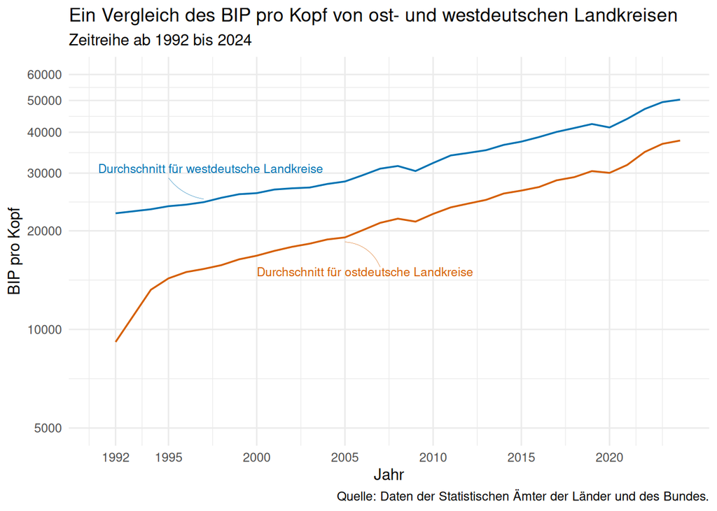

```r
bip_zeitreihe_namen |>
  group_by(ost_name, Jahr) |>
  summarise(durchschnitt = mean(bip_pro_kopf, na.rm = TRUE), .groups = "drop") |>
  ggplot(aes(x = Jahr, y = durchschnitt, color = ost_name)) +
  geom_line(linewidth = 0.6) +
  scale_color_manual(values = c("#D55E00", "#0072B2")) +
  scale_y_continuous(
    trans = "log10",
    breaks = c(5000, 10000, 20000, 30000, 40000, 50000, 60000),
    limits = c(5000, 60000)
  ) +
  scale_x_continuous(breaks = c(1992, 1995, 2000, 2005, 2010, 2015, 2020)) +
  theme_minimal() +
  theme(legend.position = "none") +
  labs(
    title = "Ein Vergleich des BIP pro Kopf von ost- und westdeutschen Landkreisen",
    subtitle = paste("Zeitreihe ab 1992 bis", jahr_max),
    caption = "Quelle: Daten der Statistischen Ämter der Länder und des Bundes.",
    x = "Jahr",
    y = "BIP pro Kopf"
  ) +
  annotate(
    "text",
    x = 2000, y = 15000, label = "Durchschnitt für ostdeutsche Landkreise",
    color = "#D55E00", hjust = 0, size = 3
  ) +
  annotate(
    "curve",
    x = 2007, xend = 2005, y = 15500, yend = 18500,
    curvature = 0.3, color = "#D55E00", linewidth = 0.1
  ) +
  annotate(
    "text",
    x = 1991, y = 31000, label = "Durchschnitt für westdeutsche Landkreise",
    color = "#0072B2", hjust = 0, size = 3
  ) +
  annotate(
    "curve",
    x = 1995, xend = 1997, y = 29000, yend = 25000,
    curvature = 0.2, color = "#0072B2", linewidth = 0.1
  )
```

Wie wir aus der Grafik deutlich sehen können hatten die ostdeutschen Landkreise zu Beginn der 1990er Jahre einen deutlich steileren Wachstumspfad als die westdeutschen Landkreise. Für manche Landkreise haben wir leider keine Information ab 1992 (bis 1999 fehlen ganz Niedersachsen und Mecklenburg-Vorpommern, 1992 zusätzlich Sachsen und das Saarland), jedoch deutet das Bild schon sehr stark darauf hin, dass es in den ersten Jahren nach der Wende einen starken Anpassungsprozess gegeben hat mit hohen Wachstumsraten des BIP pro Kopf. Dieser hat jedoch Mitte der 1990er Jahre deutlich an Fahrt verloren. Seitdem holt der Osten nur noch langsam auf (2010: 69,9%, 2024: 75,0% des westdeutschen Niveaus), während der Abstand in Euro weiter wächst. Einen ähnlichen Schluss hatten wir bereits bei der Analyse der `gt` Tabelle im Abschnitt zu den deskriptiven Tabellen gesehen.

Eine weitere Möglichkeit die Wachstumspfade zu visualisieren wäre mit sogenannten “small multiples”. Hierdurch können wir die Aufmerksamkeit auf den Wachstumspfad richten und ignorieren dabei die Höhe des Startwertes. Für diese und alle nun folgenden Analysen wollen wir uns nun wieder die Daten ab dem Jahr 2000 anschauen. Hintergrund ist, dass ab diesem Zeitpunkt Daten für alle Landkreise verfügbar sind.

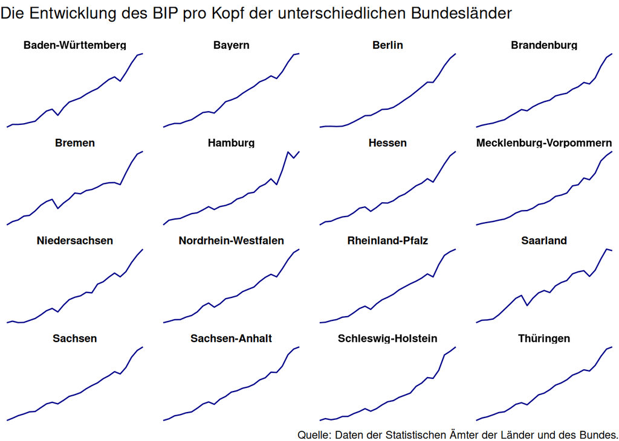

```r
plot_bip_sparklines <- bip_zeitreihe_namen |>
  filter( Jahr >= 2000 ) |>
  group_by(bundesland_name, Jahr) |>
  mutate( durchschnitt = mean(bip_pro_kopf),
          ulm = ifelse(landkreis_name == "Ulm", bip_pro_kopf,NA)) |>
  ggplot() +
  geom_line(aes(x = Jahr, y = durchschnitt, group = bundesland_name), color = "darkblue") +
  theme(legend.position = "none") +
  labs(title = "Die Entwicklung des BIP pro Kopf der unterschiedlichen Bundesländer\n",
       caption = "Quelle: Daten der Statistischen Ämter der Länder und des Bundes.",
       x = "Jahr",
       y = "BIP pro Kopf") +
  facet_wrap(~bundesland_name, scales = "free_y") +
  theme_void() +
  theme(strip.text = element_text(face = "bold"))

plot_bip_sparklines
```

Auch in diesem Beispiel sehen wir, dass alle Bundesländer über die Jahre hinweg ihr BIP pro Kopf steigern konnten und das der Effekt der Finanzkrise tendenziell in den westdeutschen Landkreisen ausgeprägter war als in den ostdeutschen. Noch besser können wir den Effekt der Finanzkrise an der folgenden Grafik sehen, bei welcher die Veränderung des BIP pro Kopf in jedem Landkreis zum Vorjahr abgetragen wird:

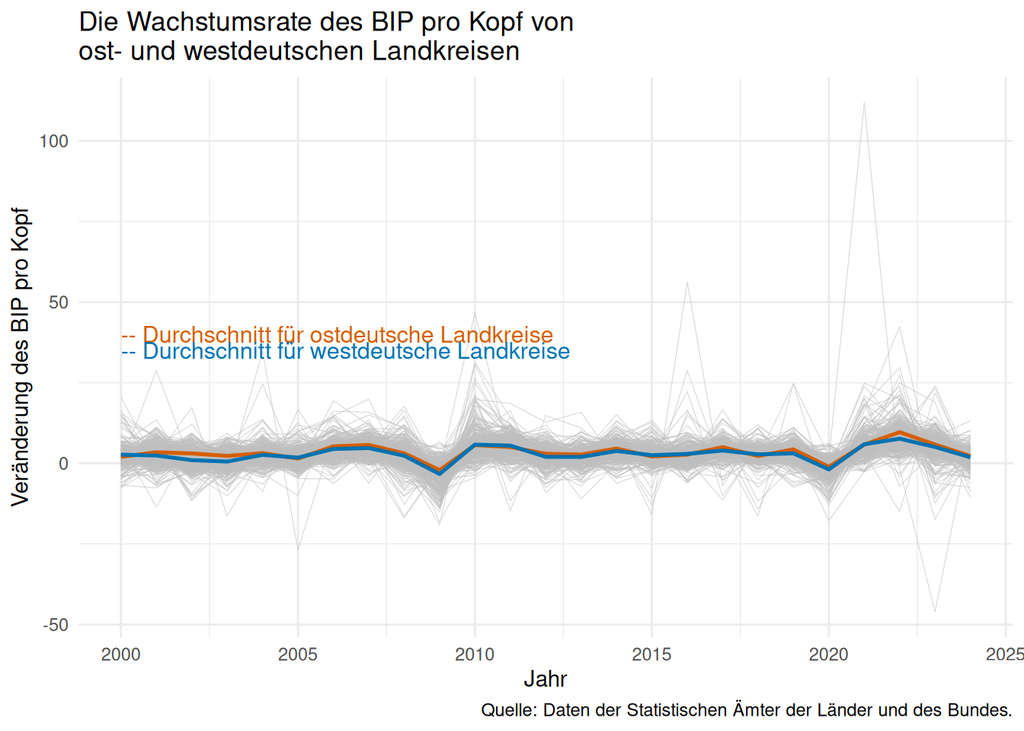

```r
bip_wachstum <- bip_zeitreihe_namen |>
  group_by(Regionalschluessel) |>
  arrange(Regionalschluessel, Jahr) |>
  # Wachstumsrate: Veränderung geteilt durch den Wert des VORJAHRES
  mutate( bip_pro_kopf_wachstum = 100*(bip_pro_kopf - lag(bip_pro_kopf)) / lag(bip_pro_kopf)) |>
  ungroup() |>
  group_by(ost_name, Jahr) |>
  mutate( durchschnitt = mean(bip_pro_kopf_wachstum, na.rm=TRUE)) |>
  ungroup()

base <- bip_wachstum |>
  filter(Jahr >= 2000) |>
  filter(!is.na(bip_pro_kopf_wachstum))

avg <- base |>
  group_by(ost_name, Jahr) |>
  summarise(durchschnitt = mean(bip_pro_kopf_wachstum, na.rm = TRUE), .groups = "drop")

ggplot() +
  # alle Landkreise (grau)
  geom_line(
    data = base,
    aes(x = Jahr, y = bip_pro_kopf_wachstum, group = Regionalschluessel),
    color = "grey", linewidth = 0.2, alpha = 0.6, na.rm = TRUE
  ) +
  # Durchschnittslinien ost/west
  geom_line(
    data = avg,
    aes(x = Jahr, y = durchschnitt, color = ost_name),
    linewidth = 0.9, na.rm = TRUE
  ) +
  scale_color_manual(values = c("#D55E00", "#0072B2")) +
  theme_minimal() +
  labs(
    color = "Durchschnitt der Landkreise",
    title = "Die Wachstumsrate des BIP pro Kopf von\nost- und westdeutschen Landkreisen",
    caption = "Quelle: Daten der Statistischen Ämter der Länder und des Bundes.",
    x = "Jahr",
    y = "Veränderung des BIP pro Kopf"
  ) +
  theme(legend.position = "none") +
  # feste Labels: annotate statt aes()
  annotate(
    "text", x = 2000, y = 40,
    label = "-- Durchschnitt für ostdeutsche Landkreise",
    color = "#D55E00", hjust = 0, size = 4
  ) +
  annotate(
    "text", x = 2000, y = 35,
    label = "-- Durchschnitt für westdeutsche Landkreise",
    color = "#0072B2", hjust = 0, size = 4
  )
```

Insgesamt haben ost- und westdeutsche Landkreise im Durchschnitt eine sehr ähnliche Wachstumsrate des BIP pro Kopf seit 2000. In den westdeutschen Landkreisen ist sie stellenweise etwas niedriger, insbesondere vor der Finanzkrise oder während Corona.

Durch die vorherigen Schaubilder sehen wir, dass die Unterschiede zwischen den ost- und westdeutschen Landkreisen schon lange bestehen (mind. seit 2000) und dass sich die ostdeutschen Landkreise dem westdeutschen BIP pro Kopf nach dem Jahr 2000 nur langsam annähern. Die Wachstumsraten sind im Osten im Mittel nur leicht höher; für eine schnelle Angleichung sind sie zu ähnlich. Beachten Sie außerdem, dass das BIP hier nominal gemessen ist: Die hohen Wachstumsraten 2022 und 2023 spiegeln vor allem die Inflation wider. Direkt nach der Wende war dies anders, zu diesem Zeitpunkt waren die Wachstumspfade der ostdeutschen Landkreise deutlich höher als die der westdeutschen. In der Übungsaufgabe beschäftigen Sie sich mit dem Einkommen auf Landkreisebene und können dort nachvollziehen, ob der Trend bei den Einkommen der Gleiche ist wie bei dem BIP pro Kopf!

Wenn wir uns nur auf das Jahr 2024 beschränken, so sehen wir auch hier im BIP pro Kopf deutliche Unterschiede. Im folgenden Schaubild ist die Verteilung des BIP pro Kopf über alle Landkreise für Ost- und Westdeutschland im Jahr 2024 abgetragen bei denen das BIP pro Kopf unter 100 000€ lag. Zusätzlich sind die jeweiligen Mittelwerte des BIP pro Kopf für ost- und westdeutsche Landkreise in blau eingezeichnet. Zum Einen können wir uns die Verteilung des BIP pro Kopf gut durch ein Histogramm anzeigen lassen, wobei die “binwidth”, d.h. die Dicke eines Balkens, auf 1000€ gesetzt wurde. Dies bedeutet, das alle Beobachtungen innerhalb von 1000€ zusammengefasst in einem Balken dargestellt werden. Z.B. werden alle westdeutschen Landkreise mit einem BIP pro Kopf zwischen 23000€ und 24000€ in einem Balken zusammengefasst (aktuell: 1, siehe Schaubild).

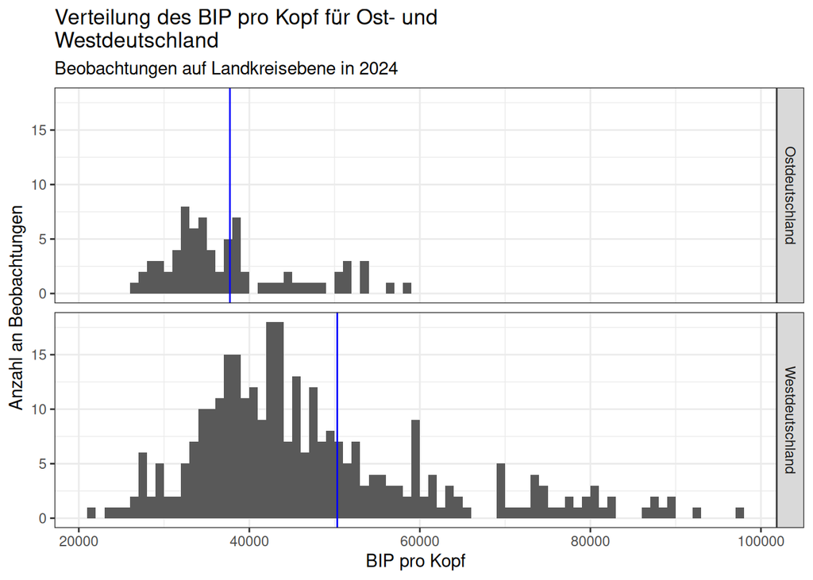

```r
gesamtdaten |>
  group_by(ost_name) |>
  summarise(durchschnitt = mean(bip_pro_kopf, na.rm = T)) |>
  ggplot(aes(x = bip_pro_kopf)) +
  geom_histogram(data = filter(gesamtdaten, bip_pro_kopf<100000), binwidth = 1000,boundary=0) +
  facet_grid(ost_name~.) +
  geom_vline(aes(xintercept = durchschnitt), color = "blue") +
  theme_bw() +
  labs(title = "Verteilung des BIP pro Kopf für Ost- und\nWestdeutschland",
       subtitle = paste("Beobachtungen auf Landkreisebene in", jahr_max),
       x = "BIP pro Kopf",
       y = "Anzahl an Beobachtungen")
```

```r
means <- gesamtdaten |>
  group_by(ost_name) |>
  summarise(durchschnitt = mean(bip_pro_kopf, na.rm = T))
```

Durch die Analyse der Verteilung des BIP werden unsere bisherigen Erkenntnisse gestützt. Die ostdeutschen Landkreise haben in 2024 ein durchschnittliches BIP pro Kopf von 37.724€, die westdeutschen Landkreise von 50.312€. Es gibt zwar auch in Westdeutschland Landkreise mit einem geringeren BIP pro Kopf als in manchen ostdeutschen Landkreisen, doch a) es gibt deutlich mehr Landkreise, die mehr als 55000€ BIP pro Kopf aufweisen, in Westdeutschland (82) als in Ostdeutschland (2) und b) auch der Vergleich der Verteilungen zeigt, dass der Großteil der Beobachtungen in Westdeutschland rechts von dem in Ostdeutschland liegt.

Da wir im oben gezeigten Histogramm die Anzahl an Beobachtungen, d.h. die Anzahl an Landkreisen, auf der y-Achse abgetragen haben könnte es durchaus sein, dass wir die zwei Schaubilder nicht so direkt miteinander Vergleichen können. Schließlich gibt es deutlich weniger ostdeutsche als westdeutsche Landkreise.

Was wir in diesem Fall tun können um die Vergleichbarkeit zu erhöhen ist die Verteilungsdichte zu zeigen, anstatt eines Histogramms. Im Grunde können Sie sich die Dichte als geglättetes Histogramm vorstellen, welche auf der y-Achse nicht mehr die Anzahl an Beobachtungen, sondern die Dichte abträgt.

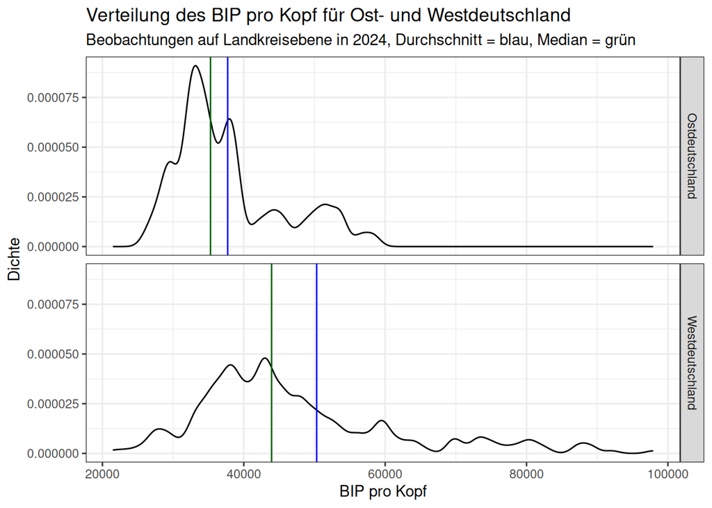

```r
gesamtdaten |>
  group_by(ost_name) |>
  summarise(durchschnitt = mean(bip_pro_kopf, na.rm = T), median = median(bip_pro_kopf, na.rm = T)) |>
  ggplot(aes(x = bip_pro_kopf)) +
  geom_density(data = filter(gesamtdaten, bip_pro_kopf<100000), kernel = "gaussian", bw = 1000) +
  facet_grid(ost_name~.) +
  geom_vline(aes(xintercept = durchschnitt), color = "blue") +
  geom_vline(aes(xintercept = median), color = "darkgreen") +
  theme_bw() +
  labs(title = "Verteilung des BIP pro Kopf für Ost- und Westdeutschland",
       subtitle = paste0("Beobachtungen auf Landkreisebene in ", jahr_max, ", Durchschnitt = blau, Median = grün"),
       x = "BIP pro Kopf",
       y = "Dichte")
```

Auch hier erhalten wir den selben Eindruck von der Verteilung des BIP pro Kopf, wie beim Histogramm. Die “bindwidth” (bw) haben wir wieder auf 1000€ gesetzt und wieder nur die Landkreise abgetragen mit einem BIP pro Kopf von unter 100000€. Neben dem Durchschnitt (in blau) haben wir hier noch den Median (in grün) der Verteilungen eingezeichnet und sehen, dass dieser in Ostdeutschland deutlich näher am Mittelwert liegt als in Westdeuschland. Dies liegt vor allem daran das es in Westdeutschland einige Landkreise mit sehr hohen BIP pro Kopf gibt.

### Verschuldung der einzelnen Landkreise

Ein weiterer Faktor, welcher die Arbeitslosenquote bestimmen könnte ist die Verschuldung des öffentlichen Haushalts. In strukturschwachen Landkreisen mit einer hohen Verschuldung sind tendenziell weniger Jobs vorhanden und die Gemeinden haben niedrigere Gewerbesteuereinnahmen. Für Investitionen müssen sich diese Gemeinden beim nicht-öffentlichen Sektor verschulden.

Um uns die Verschuldung des öffentlichen Haushalts besser vor Augen zu führen wollen wir diese auf einer Deutschlandkarte darstellen:

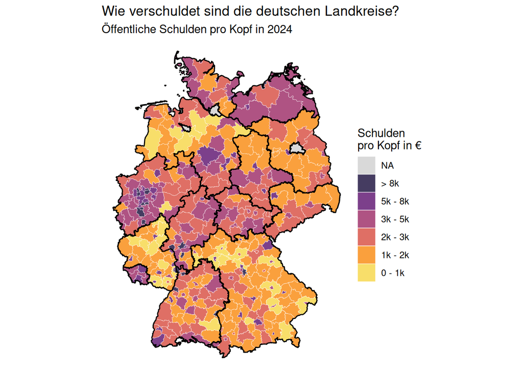

```r
schulden_landkreise <- left_join(landkreise, gesamtdaten, by="Regionalschluessel") |>
  # cut() mit Inf als oberer Grenze: Jeder Landkreis bekommt eine Klasse, auch Extremwerte
  mutate(schulden_pro_kopf = cut(Schulden_pro_kopf_lk,
                                 breaks = c(0, 1000, 2000, 3000, 5000, 8000, Inf),
                                 labels = c("0 - 1k", "1k - 2k", "2k - 3k", "3k - 5k", "5k - 8k", "> 8k")))

plot_schulden_lk <- ggplot(
  # Datensatz
  data = schulden_landkreise
) +
  geom_sf(
    mapping = aes(
      fill = schulden_pro_kopf
    ),
    color = "white",
    size = 0.1
  ) +
  # Viridis Farbschema
  scale_fill_viridis_d(
    option = "inferno",
    name = "Schulden\npro Kopf in €",
    alpha = 0.8, # Deckkraft der Füllung
    begin = 0.1,
    end = 0.9,
    direction = -1,
    na.value = "grey85",
    guide = guide_legend(reverse = T)) +
  # etwas dickere Linien für Bundeslandgrenzen
  geom_sf(
    data = bundesland,
    fill = "transparent",
    color = "black",
    size = 0.5
  ) +
  # Titel
  labs(x = NULL,
       y = NULL,
       title = "Wie verschuldet sind die deutschen Landkreise?",
       subtitle = "Öffentliche Schulden pro Kopf in 2024") +
  theme_void()

plot_schulden_lk
```

Das Schaubild zeigt die pro-Kopf Verschuldung der einzelnen Landkreise. Je dunkler die Landkreise eingefärbt sind, desto höher ist ihre Verschuldung. Die Legende gibt die Bandbreite der Verschuldung pro Farbschattierung wieder, wobei 1k = 1000€ und 8k = 8000€ bedeuten. Die Klassen haben wir mit `cut()` gebildet: Mit `Inf` als oberer Grenze fällt kein Landkreis durch das Raster, auch nicht, wenn in den Daten des nächsten Jahres ein Extremwert auftaucht. Für Berlin, Bremen, Bremerhaven und Hamburg (grau hinterlegt) haben wir keine Daten. Besonders in Rheinland-Pfalz, Bayern und Brandenburg hat mehr als die Hälfte der Landkreise eine geringe Pro-Kopf-Verschuldung von maximal 2000€. Im Saarland, in Mecklenburg-Vorpommern und Nordrhein-Westfalen ist dagegen kaum ein Landkreis so gering verschuldet; dort ist die Verschuldung pro Kopf sehr hoch. Rheinland-Pfalz zeigt allerdings auch, wie stark die Unterschiede innerhalb eines Landes sein können: Neben vielen gering verschuldeten Landkreisen liegt gut jeder fünfte über 5000€ pro Kopf. Besonders das Ruhrgebiet, die ehemalige Herzkammer der deutschen Industrie, sticht durch eine hohe Verschuldung pro Kopf hervor. Nun haben wir hier die öffentliche Verschuldung ins Verhältnis zu der Einwohnerzahl gesetzt, allerdings wird ihnen eine andere Berechnung bzw. Einschätzung der Verschuldung öfter begegnen: Die Verschuldung eines Landes bzw. ein Landkreis im Verhältnis zur Wirtschaftskraft, d.h. zum BIP, dieses Landkreises. Dies wollen wir hier auch berechnen und die Deutschlandkarte entsprechend einfärben:

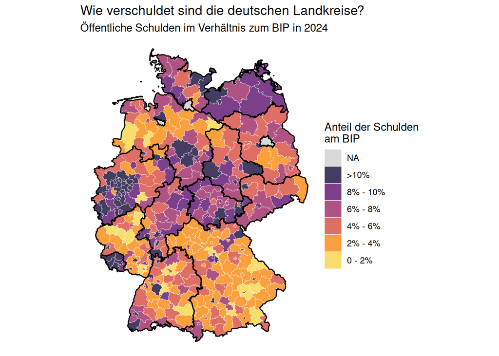

```r
schulden_landkreise_anteil <- left_join(landkreise, gesamtdaten, by="Regionalschluessel") |>
  mutate(anteil_schulden = Schulden_gesamt / bip,
         anteil_schulden = as.factor(case_when(
    anteil_schulden <= 0.02~ "0 - 2%",
    anteil_schulden > 0.02 & anteil_schulden <= 0.04 ~ "2% - 4%",
    anteil_schulden > 0.04 & anteil_schulden <= 0.06 ~ "4% - 6%",
    anteil_schulden > 0.06 & anteil_schulden <= 0.08 ~ "6% - 8%",
    anteil_schulden > 0.08 & anteil_schulden <= 0.10 ~ "8% - 10%",
    anteil_schulden > 0.10  ~ ">10%"
  )))

plot_schulden_lk <- ggplot(
  # Datensatz
  data = schulden_landkreise_anteil
) +
  geom_sf(
    mapping = aes(
      fill = fct_relevel(anteil_schulden, ">10%", after = Inf)
    ),
    color = "white",
    size = 0.1
  ) +
  # Viridis Farbschema
  scale_fill_viridis_d(
    option = "inferno",
    name = "Anteil der Schulden\nam BIP",
    alpha = 0.8, # Deckkraft der Füllung
    begin = 0.1,
    end = 0.9,
    direction = -1,
    na.value = "grey85",
    guide = guide_legend(reverse = T)) +
  geom_sf(
    data = bundesland,
    fill = "transparent",
    color = "black",
    size = 0.5
  ) +
  # Titel
  labs(x = NULL,
       y = NULL,
       title = "Wie verschuldet sind die deutschen Landkreise?",
       subtitle = "Öffentliche Schulden im Verhältnis zum BIP in 2024") +
  theme_void()

plot_schulden_lk
```

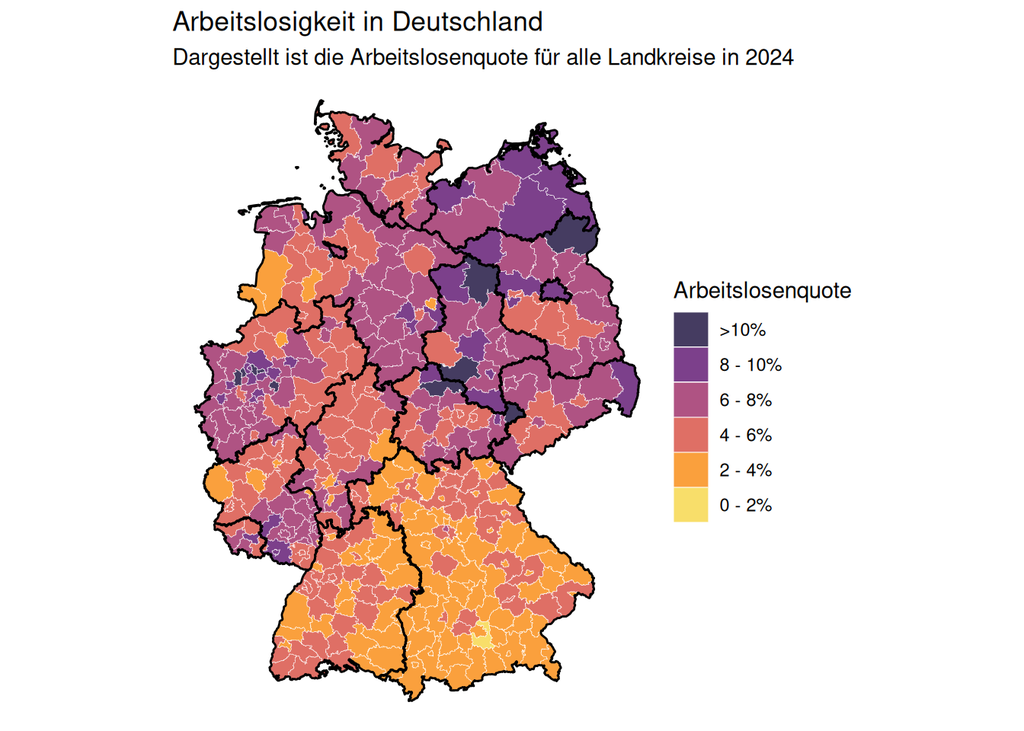

```r
schulden_landkreise <- left_join(landkreise, gesamtdaten, by="Regionalschluessel") |>
  mutate(alo_quote_lk = as.factor(case_when(
    alo_quote <= 2 ~ "0 - 2%",
    alo_quote > 2 & alo_quote <= 4 ~ "2 - 4%",
    alo_quote > 4 & alo_quote <= 6 ~ "4 - 6%",
    alo_quote > 6 & alo_quote <= 8 ~ "6 - 8%",
    alo_quote > 8 & alo_quote <= 10 ~ "8 - 10%",
    alo_quote > 10 ~ ">10%"
  )))

plot_alo_lk <- ggplot(
  # Datensatz
  data = schulden_landkreise
) +
  geom_sf(
    mapping = aes(
      fill = fct_relevel(alo_quote_lk, ">10%", after = 5)
    ),
    color = "white",
    size = 0.1
  ) +
  # Viridis Farbschema
  scale_fill_viridis_d(
    option = "inferno",
    name = "Arbeitslosenquote",
    alpha = 0.8, # Deckkraft der Füllung
    begin = 0.1,
    end = 0.9,
    direction = -1,
    na.value = "grey85",
    guide = guide_legend(reverse = T)) +
  # etwas dickere Linien für Bundeslandgrenzen
  geom_sf(
    data = bundesland,
    fill = "transparent",
    color = "black",
    size = 0.5
  ) +
  # Titel
  labs(x = NULL,
       y = NULL,
       title = "Arbeitslosigkeit in Deutschland",
       subtitle = "Dargestellt ist die Arbeitslosenquote für alle Landkreise in 2024") +
  theme_void()


plot_alo_lk
```

In dieser Karte sehen wir einen deutlichen Unterschied für ost- und westdeutsche Landkreise. In Ostdeutschland ist die Arbeitslosigkeit deutlich höher als in Westdeutschland, d.h. das Kartenpendant zu unseren vorherigen Analysen. Jedoch sind die Landkreise in Westdeutschland, welche eine hohe Verschuldung aufweisen, wie beispielsweise im Saarland oder Nordrhein-Westfalen, auch die Landkreise mit der höchsten Arbeitslosenquote in Westdeutschland. Daher könnte die Verschuldung des öffentlichen Haushalts durchaus auch ein Faktor sein, welcher die Arbeitslosenquote erklären könnte und wir sollten diesen Faktor in unserer Analyse weiterhin berücksichtigen.

# Bivariate deskriptive Analyse

## Die Korrelation

In unseren aktuellen Analysen hatten wir uns mit univariaten deskriptiven Analysen beschäftigt, d.h nur mit einer Variablen an sich. Nun wollen wir uns noch anschauen, wie die Arbeitslosenquote mit dem BIP Wachstum und dem Anteil der öffentlichen Schulden am BIP im Jahr 2024 für die einzelnen Landkreise in Deutschland zusammenhängen, d.h. eine bivariate deskriptive Analyse.

Durch die bisherigen deskriptiven Analysen haben wir eine große Streuung des BIP pro Kopf innerhalb Deutschlands festgestellt. Insbesondere gab es einen deutlichen Unterschied zwischen ost- und westdeutschen Landkreisen. Im BIP Wachstum waren sich ost- und westdeutsche Landkreise im Durchschnitt recht ähnlich, doch auch hier gab es beträchtliche Unterschiede zwischen den Landkreisen. Um etwas darüber Aussagen zu können, wie die Arbeitslosenquote mit dem BIP-Wachstum oder der öffentlichen Verschuldung zusammenhängt, wollen wir uns die Korrelation der einzelnen Variablen untereinander näher anschauen.

### Arbeitslosenquote und BIP-Wachstum

Zuerst wollen wir das zuvor berechnete BIP-Wachstum auf das aktuellste Jahr der Zeitreihe einschränken und dies zu unseren Gesamtdaten hinzufügen.

```r
bip_wachstum <- bip_wachstum |>
  filter( Jahr == jahr_max ) |>
  select(Regionalschluessel, bip_pro_kopf_wachstum, Jahr)

gesamtdaten <- left_join(gesamtdaten, bip_wachstum, by = "Regionalschluessel") |>
  mutate(anteil_schulden = Schulden_gesamt / bip * 100)   # in Prozent des BIP
```

Anschließend erstellen wir ein Streudiagramm, welches die Arbeitslosenquote und das BIP Wachstum in den einzelnen Landkreisen einander gegenüberstellt. Hier erhalten wir erste Einblicke in die Korrelation der zwei Variablen.

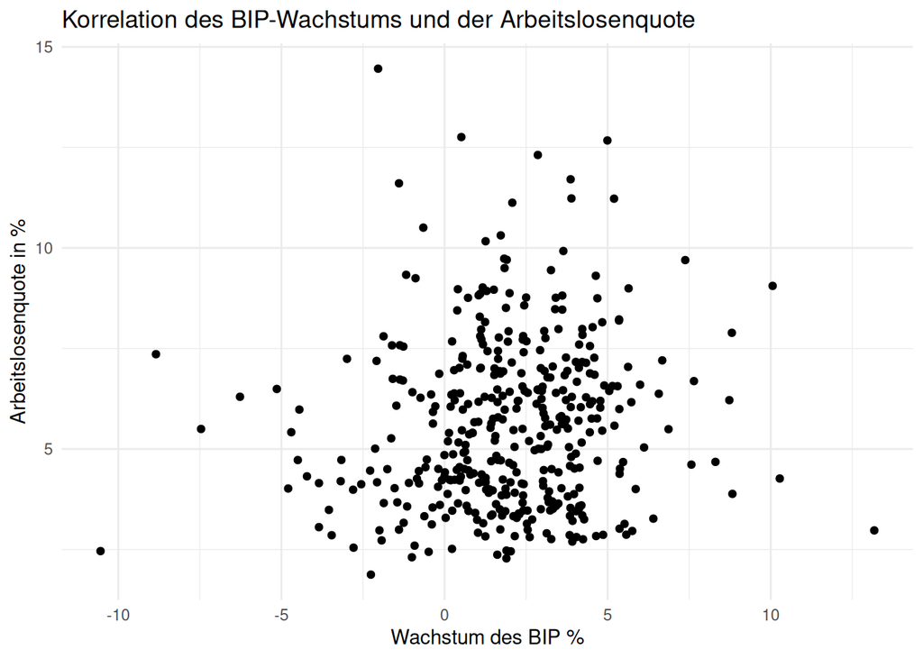

```r
gesamtdaten |>
  ggplot(aes(x = bip_pro_kopf_wachstum, y = alo_quote)) +
  geom_point() +
  labs( x = "Wachstum des BIP %",
        y = "Arbeitslosenquote in %",
        title = "Korrelation des BIP-Wachstums und der Arbeitslosenquote") +
  theme_minimal()
```

Zuerst fallen die Ausreißer ins Auge. Insbesondere im positiven Bereich gibt es Landkreise, welche ein hohes BIP-pro-Kopf-Wachstum von 2023 nach 2024 aufweisen (den höchsten Wert weist Wolfsburg mit rund 13,2% auf). Aber es gibt auch Landkreise, welche eine Schrumpfung des BIP pro Kopf um rund 10,5% aufweisen (am deutlichsten Ingolstadt). Solche Ausreißer entstehen oft dadurch, dass [einzelne Branchen (manchmal auch einzelne Firmen)](https://www.statistik.bayern.de/presse/mitteilungen/2024/pm210/) das BIP eines ganzen Landkreises stark bewegen können (man denke z.B. an die Automobilindustrie), Diese hohen oder niedrigen Wachstumsraten könnten natürlich durch vereinzelte Projekte auf Landkreisebene bedingt sein, werden sich jedoch im gesamten Datensatz mit 400 Landkreisen und kreisfreien Städten wieder relativieren. Je mehr Beobachtungen Sie in ihrem Datensatz haben, desto weniger fallen einzelne Ausreißer ins Gewicht. Durch unseren umfangreichen Datensatz können wir solche einzelnen Ausreißer auffangen. Wenn wir jedoch eine kleine Stichprobe aus diesem Datensatz extrahieren (z.B. nur alle ostdeutschen Landkreise), dann könnte schon ein deutlich anderes Bild des Zusammenhangs der beiden Variablen entstehen. Betrachten wir z.B. nur die ostdeutschen Landkreise, so ist die Korrelation mit -0,14 sogar negativ, im Westen dagegen mit 0,12 leicht positiv.

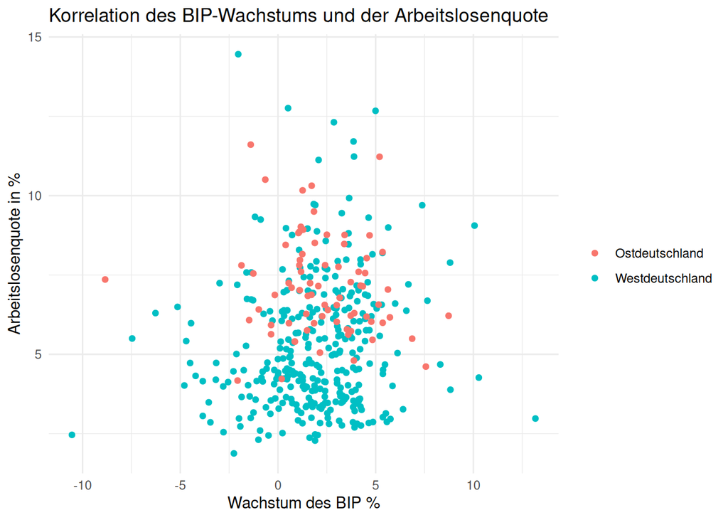

```r
gesamtdaten |>
  ggplot(aes(x = bip_pro_kopf_wachstum, y = alo_quote, color = ost_name)) +
  geom_point() +
  labs( x = "Wachstum des BIP %",
        y = "Arbeitslosenquote in %",
        title = "Korrelation des BIP-Wachstums und der Arbeitslosenquote",
        color = "") +
  theme_minimal()
```

Anhand der Punktewolke könnten wir abschätzen, dass der Zusammenhang zwischen der Arbeitslosenquote und dem BIP-pro-Kopf-Wachstum nahe Null sein müsste. D.h. wir würden vermuten dass es keinen Zusammenhang zwischen der BIP-pro-Kopf Wachstumsrate und der Arbeitslosenquote eines Landkreises in 2024 gibt.

Wenn wir uns die Korrelation zwischen den zwei Variablen ausgeben lassen, so erhalten wir die eine (schwach) positive Korrelation nahe Null:

```r
cor(gesamtdaten$alo_quote, gesamtdaten$bip_pro_kopf_wachstum,use = "pairwise.complete.obs")
```

```
## [1] 0.09867344
```

D.h. der von uns in der Grafik vermutete (nicht vorhandene) Zusammenhang zwischen der Arbeitslosenquote und dem BIP-pro-Kopf-Wachstum wird durch die Analyse der Korrelation bestätigt.

## Arbeitslosenquote und Verschuldung als Anteil am BIP

Die Korrelation der Arbeitslosenquote und dem Anteil der öffentlichen Schulden möchten wir nun auch über ein Streudiagramm untersuchen.

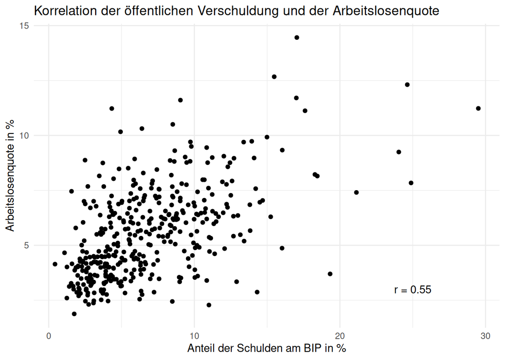

```r
cor_alo_verschuldung <- cor(gesamtdaten$alo_quote, gesamtdaten$anteil_schulden,use = "pairwise.complete.obs")

gesamtdaten |>
  ggplot(aes(x = anteil_schulden, y = alo_quote)) +
  geom_point() +
  labs( x = "Anteil der Schulden am BIP in %",
        y = "Arbeitslosenquote in %",
        title = "Korrelation der öffentlichen Verschuldung und der Arbeitslosenquote") +
  theme_minimal() +
  # annotate() zeichnet den Text genau einmal (geom_text() würde ihn für jede Zeile zeichnen)
  annotate("text", x = 25, y = 3, label = paste("r =", round(cor_alo_verschuldung, 2)))
```

In diesem Schaubild scheint es einen positiven Zusammenhang zwischen der öffentlichen Verschuldung und der Arbeitslosenquote der Landkreise zu geben. D.h. Landkreise mit einer hohen Verschuldung im Verhältnis zu ihrem BIP haben tendenziell auch eine höhere Arbeitslosenquote. Jedoch ist es auch hier schwer zu sagen, wie groß die Korrelation tatsächlich ist. Daher haben wir die Korrelation im Schaubild mit eingefügt.

Färben wir die Punkte nach Ost und West ein, so sehen wir: Der positive Zusammenhang wird vor allem von den westdeutschen Landkreisen getragen. Die ostdeutschen Landkreise haben bei ähnlicher Verschuldung sehr unterschiedliche Arbeitslosenquoten.

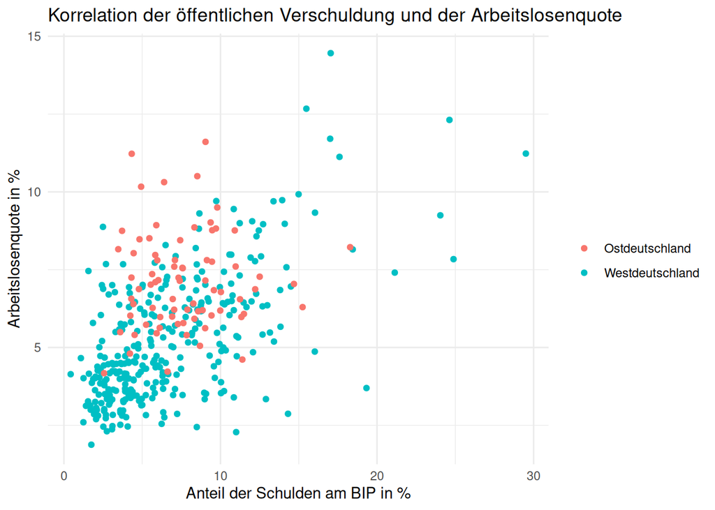

```r
gesamtdaten |>
  ggplot(aes(x = anteil_schulden, y = alo_quote, color=ost_name)) + geom_point() +
  labs( x = "Anteil der Schulden am BIP in %",
        y = "Arbeitslosenquote in %",
        title = "Korrelation der öffentlichen Verschuldung und der Arbeitslosenquote",
        color = "") +
  theme_minimal()
```

Würden wir hier nur die Korrelation zwischen Arbeitslosenquote und öffentlicher Verschuldung für ostdeutsche Landkreise betrachten, so ergebe sich eine Korrelation von:

```r
cor_data <- gesamtdaten |>
  filter(ost == 1)

cor_alo_verschuldung <- cor(cor_data$alo_quote, cor_data$anteil_schulden,use = "pairwise.complete.obs")

cor_alo_verschuldung
```

```
## [1] 0.03720315
```

D.h. wir würden hier komplett andere Schlüsse ziehen auf Basis dieser Teilgruppe. Eine Korrelation über alle Landkreise gilt also nicht automatisch für jede Teilgruppe.

### Interpretation der Korrelation

Die Korrelation als Zahl an sich hat keine intuitive quantitative Interpretation. Sie fasst den (linearen) Zusammenhang zweier Variablen in einer einzigen Kennzahl zusammen. Sie sagt, wie eng die Punkte um eine Gerade liegen, aber nicht, wie steil diese Gerade ist. Sie kann uns jedoch dabei helfen stark miteinander korrelierte Variablen in unserem Datensatz ausfindig zu machen. Dies ist insbesondere bei einer späteren Regressionsanalyse hilfreich, wenn es sich um mehrere erklärende Variablen handelt (multiple lineare Regression), welche wir alle in unsere Regression einfließen lassen möchten. Wenn wir beispielsweise eine sehr hohe positive oder negative Korrelation zwischen den erklärenden Variablen `bip_pro_kopf_wachstum` und `anteil_schulden` finden würden, dann setzen wir uns dem Problem der [Multikollinearität](https://de.wikipedia.org/wiki/Multikollinearit%C3%A4t) aus: Die Regression kann die Effekte der beiden Variablen dann kaum auseinanderhalten, die Standardfehler der Koeffizienten werden groß. Eine der Variablen einfach wegzulassen ist allerdings auch keine Lösung, da dies zu einer Verzerrung durch ausgelassene Variablen führen kann. In unserem Fall ist die Korrelation der beiden Variablen jedoch gering:

```r
cor(gesamtdaten$bip_pro_kopf_wachstum, gesamtdaten$anteil_schulden,use = "pairwise.complete.obs")
```

```
## [1] 0.1207588
```

In einer empirischen Ausarbeitung werden Sie i.d.R. keine Schaubilder zur Korrelation der einzelnen Variablen sehen, sondern nur eine Tabelle in der die Korrelationen der Variablen untereinander abgetragen sind. Eine solche Tabelle können Sie einfach mit `cor()` erzeugen und mit `kableExtra` formatieren:

```r
korrelationen <- gesamtdaten |>
  select(bip_pro_kopf_wachstum, anteil_schulden, alo_quote) |>
  cor(use = "pairwise.complete.obs") |>
  round(2)

# Nur die untere Hälfte zeigen (die Matrix ist symmetrisch)
korrelationen[upper.tri(korrelationen)] <- NA
dimnames(korrelationen) <- list(c("1. BIP-pro-Kopf-Wachstum", "2. Anteil Schulden am BIP", "3. Arbeitslosenquote"),
                                c("1", "2", "3"))

options(knitr.kable.NA = "")
korrelationen |>
  kbl(caption = "Korrelationen der untersuchten Variablen", format = "html") |>
  kable_styling(bootstrap_options = c("condensed", "responsive")) |>
  kable_paper(full_width = TRUE)
```

Korrelationen der untersuchten Variablen

1

2

3

1. BIP-pro-Kopf-Wachstum

1.00

2. Anteil Schulden am BIP

0.12

1.00

3. Arbeitslosenquote

0.10

0.55

1

In empirischen Ausarbeitungen wird die Korrelation meist nur berechnet um den Zusammenhang einzelner Variablen miteinander zu veranschaulichen. Jedoch sind die Hauptanalysen die getätigt werden keine Korrelationsmatrizen sondern Regressionstabellen. Dies liegt daran, dass Regressionskoeffizienten, anders als Korrelationen eine quantitative Interpretation zulassen. Außerdem können wir in einer Regression den Zusammenhang zwischen mehreren Variablen gleichzeitig betrachten. Unter bestimmten Annahmen (Gauß-Markov) ist der Kleinste-Quadrate-Schätzer zudem der beste lineare unverzerrte Schätzer (BLUE).

Der Analyse von Zusammenhängen mittels linearer Regression werden wir uns im nächsten Semester im dritten Teil der Case-Study widmen.

# Zusammenfassung und Ausblick

Nun haben wir uns einen Überblick über unsere Daten verschafft und schon einiges zu den regionalen Unterschieden in Deutschland gelernt. Sowohl die deskriptive Analyse mittels Tabellen als auch die grafische Analyse durch verschiedene Plots zeigen uns auch 35 Jahre nach dem Mauerfall (wir analysieren Daten aus 2024) einen deutlichen Unterschied auf Landkreisebene zwischen dem ehemaligen Ostdeutschland und Westdeutschland. Jedoch sind die Unterschiede in den Arbeitslosenquoten nicht nur zwischen Ost- und Westdeutschland erkennbar, sondern es gibt auch einige Landkreise in Westdeutschland, wie z.B. im Saarland oder Nordrhein-Westfalen, welche eine recht hohe Arbeitslosenquote aufweisen. Durch die Analyse der Korrelation der unterschiedlichen Variablen konnten wir insbesondere zwischen der Arbeitslosenquote und dem Anteil der Schulden am BIP einen positiven Zusammenhang feststellen.

Im letzten Teil der Case Study wollen wir mittels linearer Regression ein tiefgreifendes Verständnis von den möglichen Einflussfaktoren auf die Arbeitslosenquote erhalten.

# Übungsaufgaben

Im ersten Teil der Case Study hatten Sie die durchschnittlichen Einkommen auf Landkreisebene in R eingelesen. Den bereinigten Datensatz finden Sie unter `data/einkommen.rds`: die Bruttolöhne und -gehälter je Arbeitnehmer:in in Euro (nominal) für die Jahre 2000 bis 2024. Wie das BIP und die Erwerbstätigen sind die Einkommen nach dem **Arbeitsort** erfasst (Inlandskonzept). Der Datensatz enthält wie `bip_zeitreihe` neben den Kreisen (5-stelliger Regionalschlüssel) auch den Bund, die Länder und die Regierungsbezirke. Nun sollen Sie diese Daten deskriptiv analysieren:

1. **Daten vorbereiten:** Verbinden Sie die Einkommen mit `gesamtdaten`, damit Sie die Informationen zu `landkreis_name`, `bundesland_name` und `ost_name` erhalten (siehe diesen Abschnitt).
   - Behalten Sie nur die Kreise. Wie viele Kreise hat Ihr Datensatz danach? Fehlen Kreise, und wenn ja, warum? (Tipp: Denken Sie an den Sonderfall der Stadtstaaten aus Teil 1.)
2. **Tabelle:** Erstellen Sie eine deskriptive Tabelle zum Einkommen im Jahr 2024, getrennt nach Ost- und Westdeutschland.
   - Beschreiben Sie Mittelwert, Standardabweichung und Median. Was sagt das Verhältnis von Mittelwert zu Median über die Verteilung?
   - Welche Kreise haben das höchste und das niedrigste Einkommen? Achten Sie darauf, dass manche Kreisnamen doppelt vorkommen (z.B. München).
3. **Zeitreihe:** Erstellen Sie ein Liniendiagramm zur Entwicklung der Einkommen in den einzelnen Landkreisen seit 2000. Sie können sich an dem Diagramm zum BIP pro Kopf orientieren.
   - Holt der Osten beim Einkommen schneller auf als beim BIP pro Kopf? Berechnen Sie dazu das Einkommen im Osten in Prozent des Westens für 2000 und 2024, und zusätzlich den Abstand in Euro.
4. **Karte:** Erstellen Sie eine Karte zum Einkommen der einzelnen Landkreise im Jahr 2024. Sie können sich an der Karte zur Verschuldung orientieren. Wählen Sie die Klassen so, dass jeder Kreis eine Farbe erhält.
5. **Korrelation:** Erstellen Sie eine Korrelationstabelle zwischen Arbeitslosenquote, Anteil Schulden, BIP pro Kopf und Einkommen. Sie können sich an der Tabelle der Korrelationen aus diesem Abschnitt orientieren.
   - Welche Variable hängt am stärksten mit dem Einkommen zusammen? Warum ist das wenig überraschend?
   - Die Arbeitslosenquote messen wir am Wohnort, das Einkommen am Arbeitsort. Was bedeutet das für die Interpretation?

**Hinweis:** Die Daten stammen aus der Revision 2024 der Volkswirtschaftlichen Gesamtrechnungen der Länder. Wenn Sie in Teil 1 eine ältere Version heruntergeladen haben, weichen Ihre Werte ab, für einige Kreise in Niedersachsen sogar deutlich (z.B. Wolfsburg).

# Weitere Quellen:

- [Data to Viz](https://www.data-to-viz.com/)
- [A ggplot2 Tutorial for Beautiful Plotting in R](https://www.cedricscherer.com/2019/08/05/a-ggplot2-tutorial-for-beautiful-plotting-in-r/)
- [The Evolution of a ggplot](https://www.cedricscherer.com/2019/05/17/the-evolution-of-a-ggplot-ep.-1/)
- [Switzerland’s regional income (in-)equality](https://timogrossenbacher.ch/2019/04/bivariate-maps-with-ggplot2-and-sf/)
- [R Graph Gallery](https://r-graph-gallery.com/)